# HW4

jessekim

11/27/2019

# Chapter 19

## 19.3.1

### P1

source code:

```r
f1 <- function(string, prefix) {
  substr(string, 1, nchar(prefix)) == prefix
}
f2 <- function(x) {
  if (length(x) <= 1) return(NULL)
  x[-length(x)]
}
f3 <- function(x, y) {
  rep(y, length.out = length(x))
}
```

- f1: evaluates whether the given string starts with (or equals to) the given prefix string. A better name for the function would be `starts_with`.
- f2: returns a vector created by removing the last element of the given vector. A better name for the function would be `remove_last`.
- f3: returns a vector with n elements, where each element is the given data, y. Here n is the length of given data, x. A better name for the function would be `replace_with`.

## 19.4.4

### P1

```r
number <- runif(1, 0, 10000)
```

1. While `if` can handle various conditions, `ifelse` can only handle one condition at once.

```r
# if
if (number < 10) {
  print("smaller than 10!")
} else if (number < 100) {
  print("betweeen 10 and 99!")
} else if (number < 1000) {
  print("between 100 and 999!")
} else {
  print("bigger than or equal to 1000!")
}
```

```
## [1] "bigger than or equal to 1000!"
```

```r
# ifelse
ifelse(number < 1000, "smaller than 1000!", "bigger than or equal to 1000!")
```

```
## [1] "bigger than or equal to 1000!"
```

2. There should not be a return value (or execution of some code) for `if`, if the condition is not matched. `ifelse` should return something even if the condition is not matched.

```r
# if
if (number == 0) {
  print("Zero!")
}

# ifelse
ifelse(number == 0, "Zero!", "Not zero!")
```

```
## [1] "Not zero!"
```

3. While `if` statements can execute some code othen than returning a value, `ifelse` only can return a value.

```r
# if
if (number == 0) {
  tibble(x = runif(10), y = runif(10)) %>%
    ggplot(aes(x, y)) +
    geom_point()
}

# ifelse
ifelse(number == 0, 0, 1)
```

```
## [1] 1
```

### P6

```r
switch(x,
  a = ,
  b = "ab",
  c = ,
  d = "cd"
)
```

`switch` finds the matching value for the given argument, and then returns a corresponding value. For example, in the example above, the function returns “ab” if x is “b”, and returns “cd” if x is “d”. If there is no matching value, nothing happens. For example, if x is “e”, nothing happens. If there is no correseponding value, the function returns the next coming value. For example, if x is “a”, it returns “ab”.

## 19.5.5

### P4

It indicates the method in which correlation coefficient is computed. The default value is “pearson”. (By documentation – `?cor`)

# Chapter 20

## 20.3.5

### P2

```r
dplyr::near
```

```
## function (x, y, tol = .Machine$double.eps^0.5)
## {
##     abs(x - y) < tol
## }
## <bytecode: 0x7fc84bfd0be0>
## <environment: namespace:dplyr>
```

It evaluates if the difference between given two numbers(`x`, `y`) are smaller than the given tolerance(`tol`). The default value for `tol` is `.Machine$double.eps^0.5`.

## 20.5.4

### P1

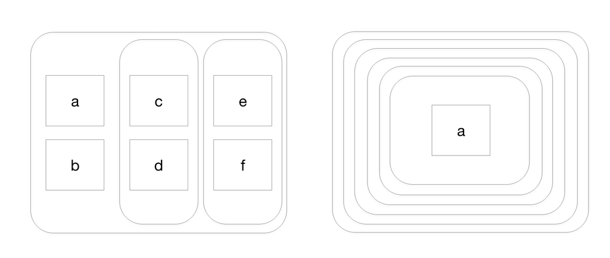

Graph

- 1. left graph: `list(a, b, list(c, d), list(e, f))`
- 2. right graph: `list(list(list(list(list(list(a))))))`

## 20.7.4

### P2

```r
tibble(
  x = c(1, 2, 3),
  y = c(1, 2, 3, 4)
)
```

An error occurs. Tibble forces the columns to have same length.

> Error: Tibble columns must have consistent lengths, only values of length one are recycled: * Length 3: Column `x` * Length 4: Column `y`

### P3

```r
tibble(
  x = list(1, 2, 3),
  y = c(4, 5, 6)
)
```

```
## # A tibble: 3 x 2
##   x             y
##   <list>    <dbl>
## 1 <dbl [1]>     4
## 2 <dbl [1]>     5
## 3 <dbl [1]>     6
```

It is OK.

# Chapter 21

## 21.2.1

### P2

```r
str_c(letters, collapse = "")
```

```
## [1] "abcdefghijklmnopqrstuvwxyz"
```

```r
sd(sample(100))
```

```
## [1] 29.01149
```

```r
accumulate(runif(100), sum)
```

```
##   [1]  0.6931995  0.7395358  0.9274376  1.4455331  1.8979222  2.3874710
##   [7]  3.0638461  3.8785272  3.9998971  4.8739483  5.7899171  6.0095952
##  [13]  6.9461261  7.2784673  7.9933150  8.8070427  8.8734978  9.8710086
##  [19] 10.2885769 10.6049525 11.0542690 11.9539618 12.4135801 12.4311387
##  [25] 12.8918461 13.2730360 14.0347360 15.0170560 15.4432442 16.0872517
##  [31] 16.4215172 17.3311774 17.5065567 18.1437813 18.3532884 18.7524558
##  [37] 19.7013019 20.6783348 21.3287871 21.8736374 22.3840562 22.4316356
##  [43] 23.0822791 23.2189801 24.1899243 24.4687348 24.7551903 24.9449419
##  [49] 24.9463698 25.6913613 26.5753698 27.1518663 27.9659080 27.9958083
##  [55] 28.1283333 28.1795510 29.1636545 30.0890189 30.2182649 30.3075527
##  [61] 30.4401942 30.8234444 31.6674185 32.6080591 33.2409534 33.4604530
##  [67] 33.8997857 34.8254179 35.3269695 36.0807326 36.7498902 36.9625635
##  [73] 37.5893659 37.7088425 38.0093430 38.8303785 39.2707559 40.1577387
##  [79] 41.1242876 41.2584490 42.0112348 42.3298562 42.6607987 42.8049651
##  [85] 43.7948758 44.2726672 44.4314295 44.6539410 44.7319344 45.4879315
##  [91] 46.3774900 46.3922212 46.9609179 47.2368670 47.6685944 48.1635212
##  [97] 48.3780753 49.2809033 49.7600463 49.7748131
```

## 21.3.5

### P3

```r
show_mean <- function(df) {
  for (i in seq_along(df)) {
    if (is.numeric(df[[i]])) {
      colname <- colnames(df)[i]
      mean <- mean(df[[i]])

      print(sprintf("#> %-13s %.2f", sprintf("%s:", colname), mean))
    }
  }
}

show_mean(iris)
```

```
## [1] "#> Sepal.Length: 5.84"
## [1] "#> Sepal.Width:  3.06"
## [1] "#> Petal.Length: 3.76"
## [1] "#> Petal.Width:  1.20"
```

## 21.4.1

### P1

```r
(m <- matrix(c(1, 2, 3, 4, 5, 6), nrow = 2))
```

```
##      [,1] [,2] [,3]
## [1,]    1    3    5
## [2,]    2    4    6
```

When `margin` argument is 1, it iterates over each row. That is:

```r
m %>% apply(1, mean)
```

```
## [1] 3 4
```

```r
# equivalent
result <- vector("numeric", nrow(m))
for (i in 1:nrow(m)) {
  result[i] <- mean(m[i, ])
}
result
```

```
## [1] 3 4
```

When `margin` argument is 2, it iterates over each column. That is:

```r
m %>% apply(2, mean)
```

```
## [1] 1.5 3.5 5.5
```

```r
# equivalent
result <- vector("numeric", ncol(m))
for (i in 1:ncol(m)) {
  result[i] <- mean(m[,i])
}
result
```

```
## [1] 1.5 3.5 5.5
```

## 21.5.3

### P1

```r
mtcars %>%
  map(mean)
```

```
## $mpg
## [1] 20.09062
##
## $cyl
## [1] 6.1875
##
## $disp
## [1] 230.7219
##
## $hp
## [1] 146.6875
##
## $drat
## [1] 3.596563
##
## $wt
## [1] 3.21725
##
## $qsec
## [1] 17.84875
##
## $vs
## [1] 0.4375
##
## $am
## [1] 0.40625
##
## $gear
## [1] 3.6875
##
## $carb
## [1] 2.8125
```

```r
nycflights13::flights %>%
  map(typeof)
```

```
## $year
## [1] "integer"
##
## $month
## [1] "integer"
##
## $day
## [1] "integer"
##
## $dep_time
## [1] "integer"
##
## $sched_dep_time
## [1] "integer"
##
## $dep_delay
## [1] "double"
##
## $arr_time
## [1] "integer"
##
## $sched_arr_time
## [1] "integer"
##
## $arr_delay
## [1] "double"
##
## $carrier
## [1] "character"
##
## $flight
## [1] "integer"
##
## $tailnum
## [1] "character"
##
## $origin
## [1] "character"
##
## $dest
## [1] "character"
##
## $air_time
## [1] "double"
##
## $distance
## [1] "double"
##
## $hour
## [1] "double"
##
## $minute
## [1] "double"
##
## $time_hour
## [1] "double"
```

```r
iris %>%
  map(function(col) length(unique(col)))
```

```
## $Sepal.Length
## [1] 35
##
## $Sepal.Width
## [1] 23
##
## $Petal.Length
## [1] 43
##
## $Petal.Width
## [1] 22
##
## $Species
## [1] 3
```

```r
c(-10, 0, 10, 100) %>%
  map(rnorm, n = 10)
```

```
## [[1]]
##  [1]  -9.144524  -9.273696 -10.085443 -10.078495 -10.662691 -10.785494
##  [7] -10.861462 -10.839752  -8.560765 -10.265028
##
## [[2]]
##  [1]  0.6875313  0.1337242  0.6281872 -0.6114836 -1.0595041  0.9741072
##  [7]  0.6072956  0.5326216 -0.1292746  0.1002704
##
## [[3]]
##  [1]  9.779559 10.806515  9.700840 11.105160 11.197330  7.518280 10.140783
##  [8]  9.991499  9.904512  8.820929
##
## [[4]]
##  [1]  98.98613  98.44197 100.44618  99.33347  99.24462  99.81152 101.03044
##  [8]  98.88728  99.56090  99.73477
```

## 21.9.3

### P3

```r
col_sum3 <- function(df, f) {
  is_num <- sapply(df, is.numeric)
  df_num <- df[, is_num]

  sapply(df_num, f)
}

df <- tibble(
  x = 1:3,
  y = 3:1,
  z = c("a", "b", "c")
)

# OK
col_sum3(df, mean)

# Has problems: don't always return numeric vector
col_sum3(df[1:2], mean) # OK
col_sum3(df[1], mean) # OK
col_sum3(df[0], mean) # ! error occurs
col_sum3(df[3], mean) # ! returns empty list
```

When an empty data frame is given, an error occurs as the function subsets the data frame with `[]` using list object(`is_num`), which is invalid for an empty data frame.

# Chapter 23

## 23.4.5

### P1

```r
mod1 <- lm(y ~ x, sim2)
mod2 <- lm(y ~ x - 1, sim2)

mod1$coefficients
```

```
## (Intercept)          xb          xc          xd
##   1.1521664   6.9638728   4.9750241   0.7588142
```

```r
mod2$coefficients
```

```
##       xa       xb       xc       xd
## 1.152166 8.116039 6.127191 1.910981
```

```r
# predictions
(grid <- sim2 %>%
  data_grid(x) %>%
  gather_predictions(mod1, mod2))
```

```
## # A tibble: 8 x 3
##   model x      pred
##   <chr> <chr> <dbl>
## 1 mod1  a      1.15
## 2 mod1  b      8.12
## 3 mod1  c      6.13
## 4 mod1  d      1.91
## 5 mod2  a      1.15
## 6 mod2  b      8.12
## 7 mod2  c      6.13
## 8 mod2  d      1.91
```

The fitted model with intercept:

$$Y = 1.1522 + 6.9639X_b + 4.9750X_c + 0.7588X_d$$

The regression coefficients of $X_b$, $X_c$, $X_d$ increased by 1.1522, which is the intercept value of the model with intercept, and regressor $X_a$ is added to the model with the value 1.1522.

Actually, the coefficients of the model without intercept are means of responses(`y`) with corresponding regressor(`x`) value, while the coefficients of the model with intercept are differences of means of responses with corresponding regressor value from the mean of responses with `x = "a"`.

Thus the prediction values remain unchanged.

# Chapter 24

## 24.2.3

### P2

A percentage change in `carat` would increase the `price` of a diamond by about $a_1$%.

Note that if x is sufficiently small,

$$log(1 + x) = log(1) + log(1)'x + ... ≈ x$$

Thus 1% changes in `x` would increase `y` approximately by $a_1$%:

$$log(y + \Delta{y}) - log(y) = a_1(log(x + 0.01x) - log(x))
\\
log(1 + \frac{\Delta{y}}{y}) = a_1log(1 + 0.01) ≈ 0.01a_1
\\
\rightarrow log(1 + \frac{\Delta{y}}{y}) ≈ \frac{\Delta{y}}{y} ≈ 0.01a_1
\\
\rightarrow \Delta{y} ≈ 0.01a_iy = a\%*y$$

```r
mod3 <- lm(log(price) ~ log(carat), diamonds)

mod3$coefficients
```

```
## (Intercept)  log(carat)
##    8.448661    1.675817
```

A percentage change in carat would increase the price by about 1.67%.

## 24.3.5

### P2

```r
daily <- nycflights13::flights %>%
  mutate(
    date = make_date(year, month, day)
  ) %>%
  group_by(date) %>%
  summarize(n = n()) %>%
  mutate(
    wday = wday(date, label = TRUE)
  )
daily
```

```
## # A tibble: 365 x 3
##    date           n wday
##    <date>     <int> <ord>
##  1 2013-01-01   842 Tue
##  2 2013-01-02   943 Wed
##  3 2013-01-03   914 Thu
##  4 2013-01-04   915 Fri
##  5 2013-01-05   720 Sat
##  6 2013-01-06   832 Sun
##  7 2013-01-07   933 Mon
##  8 2013-01-08   899 Tue
##  9 2013-01-09   902 Wed
## 10 2013-01-10   932 Thu
## # … with 355 more rows
```

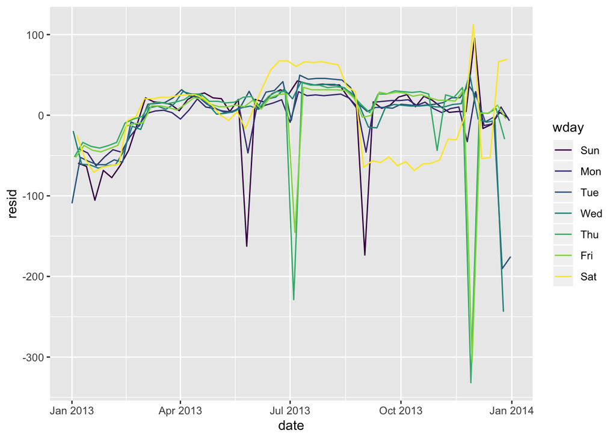

```r
mod4 <- lm(n ~ wday, daily)
daily <- daily %>%
  add_residuals(mod4)

ggplot(daily, aes(date, resid)) +
  geom_line(aes(color = wday))
```

```r
term <- function(date) {
  cut(
    date,
    breaks = ymd(20130101, 20130605, 20130825, 20140101),
    labels = c("srping", "summer", "fall")
  )
}

daily <- daily %>%
  mutate(term = term(date))

daily %>%
  top_n(3, resid)
```

```
## # A tibble: 3 x 5
##   date           n wday  resid term
##   <date>     <int> <ord> <dbl> <fct>
## 1 2013-11-30   857 Sat   112.  fall
## 2 2013-12-01   987 Sun    95.5 fall
## 3 2013-12-28   814 Sat    69.4 fall
```

The three days are weekend days after big holidays in America. That is, “2013-11-30” and “2013-12-01” are respectively saturday, sunday after Thanksgiving day, “2013-11-28”. “2013-12-28” is saturday after Christmas, “2013-12-25”.

# Extra Questions

### 1.

#### a.

As distances between vertically nearest rules on the paper are all 1cm, any point on the paper should have the distance to the vertically nearest line between 0 and 0.5. As the Frances’ point is vertically randomly and uniformly distributed, its distance to the nearest horizontal line is randomly and uniformly distributed between 0 and 0.5.

#### b ~ c.

```r
random_lines <- function(n, width, height) {

  # b & c. Generate centers and angles, which determines lines.
  centers <- tibble(
    id = 1:n,
    x = runif(n, 0, width),
    y = runif(n, 0, height),
    angle = runif(n, 0, 180)
  )

  # Calculate left endpoints of each line.
  left_points <- tibble(
    id = 1:n,
    end = "left",
    x = centers$x - 0.25*sinpi(centers$angle),
    y = centers$y + 0.25*cospi(centers$angle)
  )

  # Calculate right endpoints of each line.
  right_points <- tibble(
    id = 1:n,
    end = "right",
    x = centers$x + 0.25*sinpi(centers$angle),
    y = centers$y - 0.25*cospi(centers$angle)
  )

  # Plot of randomly generated lines.
  plot <- rbind(left_points, right_points) %>%
    ggplot(aes(x, y)) +
    geom_point() +
    geom_line(aes(group = id))

  # Summary of randomly generated lines.
  lines_summary <- centers %>%
    left_join(
      left_points %>%
        left_join(
          right_points,
          by = "id",
          suffix = c(".left", ".right")
        ) %>%
        select(-end.left, -end.right),
      by = "id",
      suffix = c(".center", "")
    )

  return(
    list(lines_summary, plot)
  )
}
```

```r
lines <- random_lines(1000, 10, 10)
lines[1] # Summary table
```

```
## [[1]]
## # A tibble: 1,000 x 8
##       id     x     y angle x.left y.left x.right y.right
##    <int> <dbl> <dbl> <dbl>  <dbl>  <dbl>   <dbl>   <dbl>
##  1     1 7.37   7.36  80.6  7.13    7.28   7.60     7.44
##  2     2 8.00   1.73 139.   8.24    1.64   7.77     1.82
##  3     3 3.04   9.64  80.2  2.87    9.82   3.22     9.46
##  4     4 0.115  7.96 144.  -0.133   7.99   0.364    7.94
##  5     5 5.77   5.21 141.   5.87    4.98   5.68     5.44
##  6     6 6.24   5.79 147.   6.46    5.67   6.02     5.92
##  7     7 2.91   7.68  31.3  3.13    7.56   2.68     7.79
##  8     8 2.90   8.66  97.4  3.13    8.58   2.66     8.74
##  9     9 2.42   4.69  46.8  2.30    4.48   2.55     4.91
## 10    10 1.66   9.42 163.   1.44    9.30   1.88     9.53
## # … with 990 more rows
```

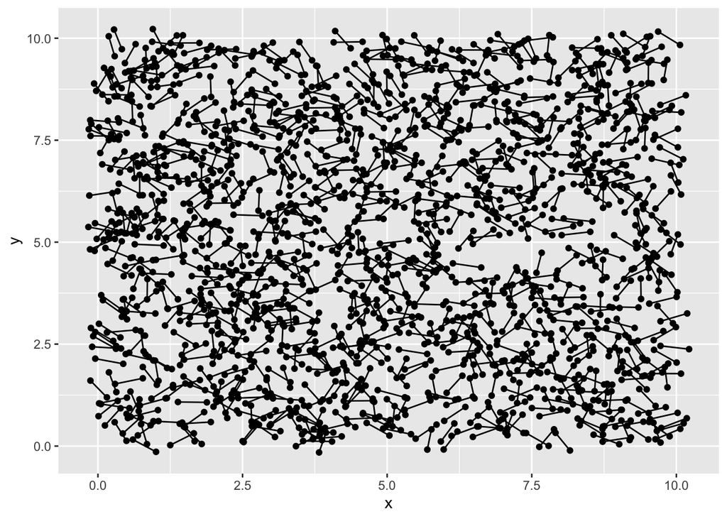

```r
lines[2] # Plot
```

#### d.

Two endpoints of each line are calculated above, given center points and angles. A line crosses a horizontal line when integer ceiling of y coordinate value of a endpoint which is bigger than another’s and integer floor of y coordinate value of a endpoint which is smaller than another’s are same. That is:

$$floor(max(y.left, y.right)) = ceiling(min(y.left, y.right))$$

#### e.

```r
cal_fraction <- function(n, width, height) {

  # Calculate fraction of crossing lines.
  fraction <- random_lines(n, width, height)[[1]] %>%
    mutate(
      floor = floor(pmax(y.left, y.right)),
      ceiling = ceiling(pmin(y.left, y.right)),
      cross = near(floor, ceiling)
    ) %>%
    summarize(
      fraction = mean(cross)
    )

  return(fraction$fraction)
}

test <- replicate(100, cal_fraction(1000, 100, 100))

mean(test)
```

```
## [1] 0.31859
```

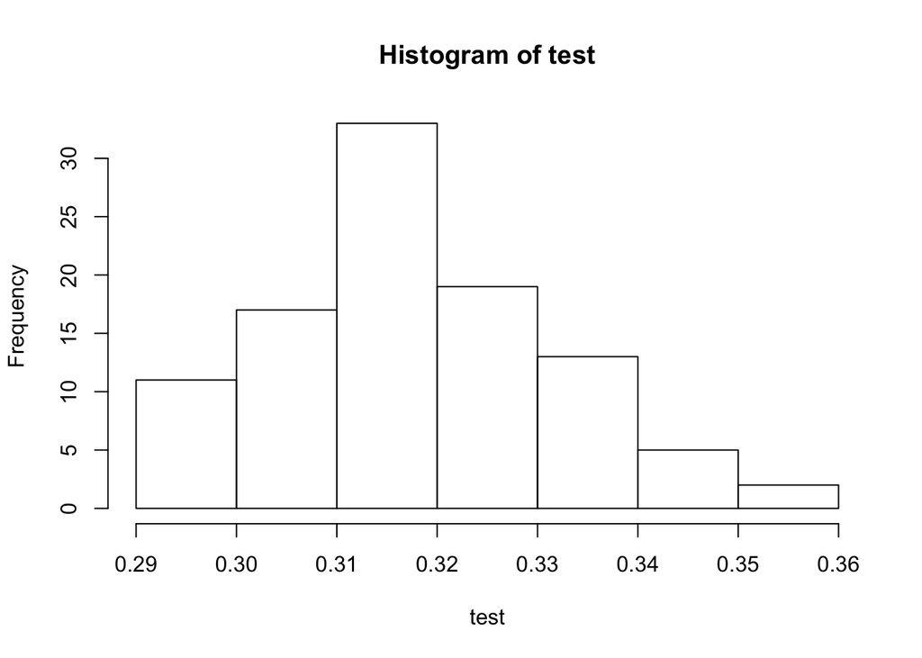

```r
hist(test)
```

#### f.

As the length of a line is 0.5, the probability of crossing is $1/\pi ≈ 0.3183$.

Reference: https://mste.illinois.edu/activity/buffon/

### 2.

#### a.

```r
is_versicolor <- iris$Species == "versicolor"
(swidth.versicolor <- iris$Sepal.Width[is_versicolor])
```

```
##  [1] 3.2 3.2 3.1 2.3 2.8 2.8 3.3 2.4 2.9 2.7 2.0 3.0 2.2 2.9 2.9 3.1 3.0
## [18] 2.7 2.2 2.5 3.2 2.8 2.5 2.8 2.9 3.0 2.8 3.0 2.9 2.6 2.4 2.4 2.7 2.7
## [35] 3.0 3.4 3.1 2.3 3.0 2.5 2.6 3.0 2.6 2.3 2.7 3.0 2.9 2.9 2.5 2.8
```

To check the result,

```r
swidth.versicolor.unvectorized <- NULL
for (i in seq_len(nrow(iris)) ) {
  if (iris$Species[i]=="versicolor") {
    swidth.versicolor.unvectorized <- c(
      swidth.versicolor.unvectorized, iris$Sepal.Width[i]
    )
  }
}

identical(swidth.versicolor, swidth.versicolor.unvectorized)
```

```
## [1] TRUE
```

#### b.

```r
data(iris)
head(iris$Sepal.Length[iris$Species])
```

```
## [1] 5.1 5.1 5.1 5.1 5.1 5.1
```

```r
unclass(iris$Species)
```

```
##   [1] 1 1 1 1 1 1 1 1 1 1 1 1 1 1 1 1 1 1 1 1 1 1 1 1 1 1 1 1 1 1 1 1 1 1 1
##  [36] 1 1 1 1 1 1 1 1 1 1 1 1 1 1 1 2 2 2 2 2 2 2 2 2 2 2 2 2 2 2 2 2 2 2 2
##  [71] 2 2 2 2 2 2 2 2 2 2 2 2 2 2 2 2 2 2 2 2 2 2 2 2 2 2 2 2 2 2 3 3 3 3 3
## [106] 3 3 3 3 3 3 3 3 3 3 3 3 3 3 3 3 3 3 3 3 3 3 3 3 3 3 3 3 3 3 3 3 3 3 3
## [141] 3 3 3 3 3 3 3 3 3 3
## attr(,"levels")
## [1] "setosa"     "versicolor" "virginica"
```

```r
iris$Sepal.Length[1] # "setosa"
```

```
## [1] 5.1
```

```r
iris$Sepal.Length[2] # "versicolor"
```

```
## [1] 4.9
```

```r
iris$Sepal.Length[3] # "virginica"
```

```
## [1] 4.7
```

`iris$Species` is a class factor, and the corresponding values of “setosa”, “versicolor”, “virginica” are 1, 2, 3, respectively.

So the value of `iris$Sepal.Length[1]`, 5.1, is presented. That is, the result is equivalent to `iris$Sepal.Length[c(1, 1, 1, 1, 1, 1)]`.